# handling_imbalance_dataset

```python
# import libraries
import warnings
warnings.filterwarnings('ignore')
import pandas as pd
import numpy as np
import matplotlib.pyplot as plt
%matplotlib inline
import seaborn as sns
```

```python
train = pd.read_csv('./titanic/train.csv')
test = pd.read_csv('./titanic/test.csv')
```

```python
full_data = pd.concat([train.loc[:,test.columns], test]).reset_index(drop=True)
```

```python
full_data.head()
```

|  | PassengerId | Pclass | Name | Sex | Age | SibSp | Parch | Ticket | Fare | Cabin | Embarked |
| --- | --- | --- | --- | --- | --- | --- | --- | --- | --- | --- | --- |
| 0 | 1 | 3 | Braund, Mr. Owen Harris | male | 22.0 | 1 | 0 | A/5 21171 | 7.2500 | NaN | S |
| 1 | 2 | 1 | Cumings, Mrs. John Bradley (Florence Briggs Th... | female | 38.0 | 1 | 0 | PC 17599 | 71.2833 | C85 | C |
| 2 | 3 | 3 | Heikkinen, Miss. Laina | female | 26.0 | 0 | 0 | STON/O2. 3101282 | 7.9250 | NaN | S |
| 3 | 4 | 1 | Futrelle, Mrs. Jacques Heath (Lily May Peel) | female | 35.0 | 1 | 0 | 113803 | 53.1000 | C123 | S |
| 4 | 5 | 3 | Allen, Mr. William Henry | male | 35.0 | 0 | 0 | 373450 | 8.0500 | NaN | S |

```python
full_data.tail()
```

|  | PassengerId | Pclass | Name | Sex | Age | SibSp | Parch | Ticket | Fare | Cabin | Embarked |
| --- | --- | --- | --- | --- | --- | --- | --- | --- | --- | --- | --- |
| 1304 | 1305 | 3 | Spector, Mr. Woolf | male | NaN | 0 | 0 | A.5. 3236 | 8.0500 | NaN | S |
| 1305 | 1306 | 1 | Oliva y Ocana, Dona. Fermina | female | 39.0 | 0 | 0 | PC 17758 | 108.9000 | C105 | C |
| 1306 | 1307 | 3 | Saether, Mr. Simon Sivertsen | male | 38.5 | 0 | 0 | SOTON/O.Q. 3101262 | 7.2500 | NaN | S |
| 1307 | 1308 | 3 | Ware, Mr. Frederick | male | NaN | 0 | 0 | 359309 | 8.0500 | NaN | S |
| 1308 | 1309 | 3 | Peter, Master. Michael J | male | NaN | 1 | 1 | 2668 | 22.3583 | NaN | C |

```python
train.head()
```

|  | PassengerId | Survived | Pclass | Name | Sex | Age | SibSp | Parch | Ticket | Fare | Cabin | Embarked |
| --- | --- | --- | --- | --- | --- | --- | --- | --- | --- | --- | --- | --- |
| 0 | 1 | 0 | 3 | Braund, Mr. Owen Harris | male | 22.0 | 1 | 0 | A/5 21171 | 7.2500 | NaN | S |
| 1 | 2 | 1 | 1 | Cumings, Mrs. John Bradley (Florence Briggs Th... | female | 38.0 | 1 | 0 | PC 17599 | 71.2833 | C85 | C |
| 2 | 3 | 1 | 3 | Heikkinen, Miss. Laina | female | 26.0 | 0 | 0 | STON/O2. 3101282 | 7.9250 | NaN | S |
| 3 | 4 | 1 | 1 | Futrelle, Mrs. Jacques Heath (Lily May Peel) | female | 35.0 | 1 | 0 | 113803 | 53.1000 | C123 | S |
| 4 | 5 | 0 | 3 | Allen, Mr. William Henry | male | 35.0 | 0 | 0 | 373450 | 8.0500 | NaN | S |

```python
train.columns
```

```
Index(['PassengerId', 'Survived', 'Pclass', 'Name', 'Sex', 'Age', 'SibSp',
       'Parch', 'Ticket', 'Fare', 'Cabin', 'Embarked'],
      dtype='object')
```

```python
len(train.columns)
```

```
12
```

```python
print('Percentage of class Survived: ', round(len(train.loc[train['Survived']==1,:])/len(train),3))
print('Percentage of class not Survived: ', round(len(train.loc[train['Survived']==0,:])/len(train),3))
```

```
Percentage of class Survived:  0.384
Percentage of class not Survived:  0.616
```

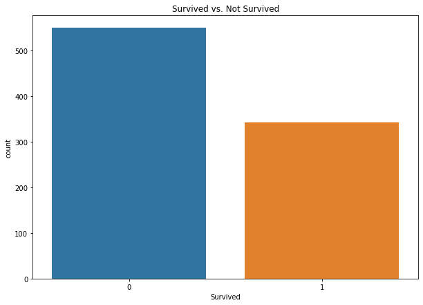

```python
# Above percentages clearly show that data is imbalanced, we will be handling this later in this notebook
# let's plot them
fig, ax = plt.subplots(1, 1, figsize=(10, 7))
sns.countplot(train['Survived'])
ax.set_title('Survived vs. Not Survived')
plt.show()
```

### 1. Numerical Variables

```python
num_vars = train.loc[:,train.dtypes != 'object']
```

```python
num_vars.head()
```

|  | PassengerId | Survived | Pclass | Age | SibSp | Parch | Fare |
| --- | --- | --- | --- | --- | --- | --- | --- |
| 0 | 1 | 0 | 3 | 22.0 | 1 | 0 | 7.2500 |
| 1 | 2 | 1 | 1 | 38.0 | 1 | 0 | 71.2833 |
| 2 | 3 | 1 | 3 | 26.0 | 0 | 0 | 7.9250 |
| 3 | 4 | 1 | 1 | 35.0 | 1 | 0 | 53.1000 |
| 4 | 5 | 0 | 3 | 35.0 | 0 | 0 | 8.0500 |

```python
num_vars.drop('PassengerId', axis=1, inplace=True)
test.drop('PassengerId', axis=1, inplace=True)
```

#### 1.1 Pclass vs Survived

```python
num_vars.loc[:,['Pclass', 'Survived']].groupby('Pclass').mean()
```

| Pclass | Survived |
| --- | --- |
| 1 | 0.629630 |
| 2 | 0.472826 |
| 3 | 0.242363 |

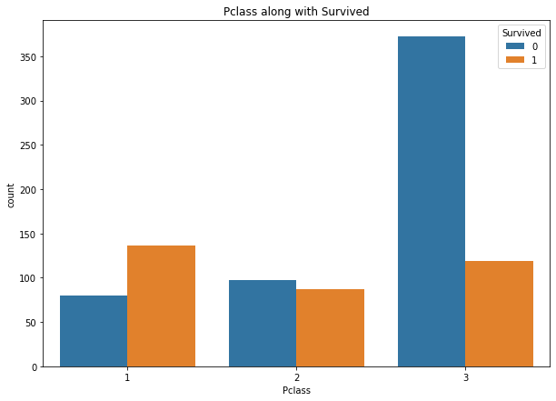

```python
fig, ax = plt.subplots(1, 1, figsize=(10, 7))
sns.countplot('Pclass', hue='Survived', data=num_vars)
ax.set_title('Pclass along with Survived')
plt.show()
```

Highest survival rate for those belong to Pclass of 1

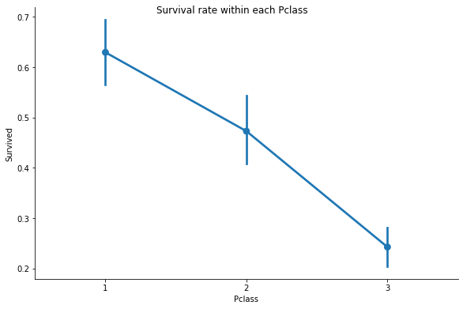

```python
# let's visualize how survival rate varies as per the Pclass
fig = sns.factorplot('Pclass', 'Survived', data=num_vars, size=5.5, aspect=1.5)
fig.fig.suptitle('Survival rate within each Pclass')
plt.show()
```

#### 1.2 Age vs Survived

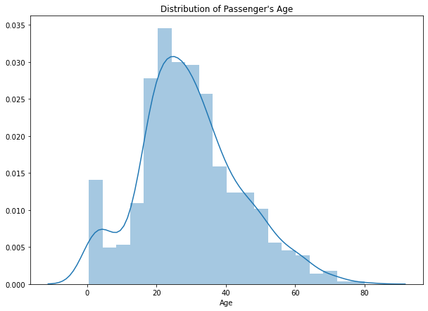

```python
fig, ax = plt.subplots(1, 1, figsize=(10, 7))
sns.distplot(num_vars['Age'])
ax.set_title("Distribution of Passenger's Age")
plt.show()
```

```python
# null values of age in training set
num_vars['Age'].isnull().sum()
```

```
177
```

```python
# null values of age in test set
test['Age'].isnull().sum()
```

```
86
```

```python
# null values of age in total
full_data['Age'].isnull().sum()
```

```
263
```

```python
mean_age = full_data['Age'].mean()
mean_age
```

```
29.881137667304014
```

```python
median_age = full_data['Age'].median()
median_age
```

```
28.0
```

```python
# mean is little greater than median, that's why we will be using median to fill null values
num_vars.loc[num_vars['Age'].isnull(),'Age'] = median_age
num_vars['Age'].isnull().sum()
```

```
0
```

```python
# mean is little greater than median, that's why we will be using median to fill null values
test.loc[test['Age'].isnull(),'Age'] = median_age
test['Age'].isnull().sum()
```

```
0
```

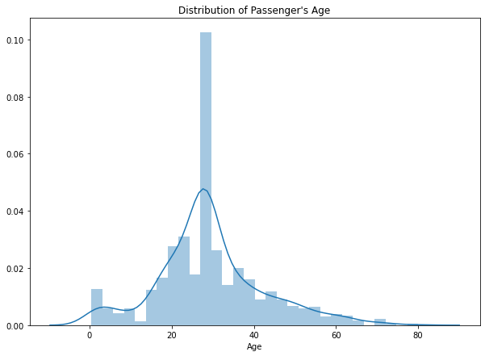

```python
fig, ax = plt.subplots(1, 1, figsize=(10, 7))
sns.distplot(num_vars['Age'])
ax.set_title("Distribution of Passenger's Age")
plt.show()
```

```python
num_vars['Age'].mean() - mean_age
```

```
-0.5195551757215249
```

```python
num_vars['Age'].median()
```

```
28.0
```

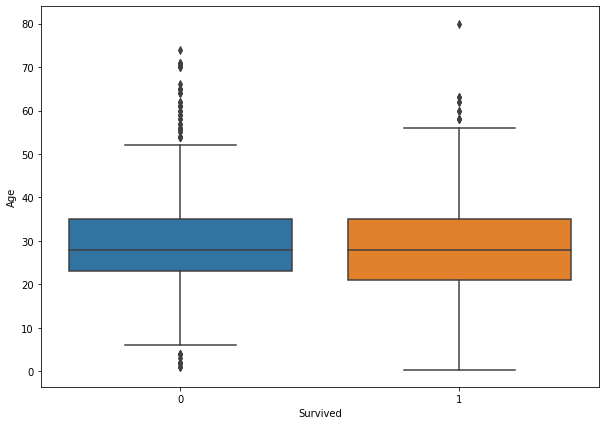

```python
# Now, Age does not have null values & got more normalize than before
fig, ax = plt.subplots(figsize=(10, 7))
sns.boxplot('Survived', 'Age', data=num_vars)
plt.show()
```

```python
# It seems that Age is not significant to detect survival of passenger. Let's catgorize them
num_vars['Age_Category'] = 0
test['Age_Category'] = 0
```

```python
num_vars.loc[num_vars['Age']<15, 'Age_Category'] = 0
num_vars.loc[(num_vars['Age']>=15) & (num_vars['Age']<25), 'Age_Category'] = 1
num_vars.loc[(num_vars['Age']>=25) & (num_vars['Age']<65), 'Age_Category'] = 2
num_vars.loc[num_vars['Age']>=65, 'Age_Category'] = 3
```

```python
test.loc[test['Age']<15, 'Age_Category'] = 0
test.loc[(test['Age']>=15) & (test['Age']<25), 'Age_Category'] = 1
test.loc[(test['Age']>=25) & (test['Age']<65), 'Age_Category'] = 2
test.loc[test['Age']>=65, 'Age_Category'] = 3
```

```python
num_vars.loc[:,['Age_Category', 'Survived']].groupby('Age_Category').mean()
```

| Age_Category | Survived |
| --- | --- |
| 0 | 0.576923 |
| 1 | 0.365000 |
| 2 | 0.370432 |
| 3 | 0.090909 |

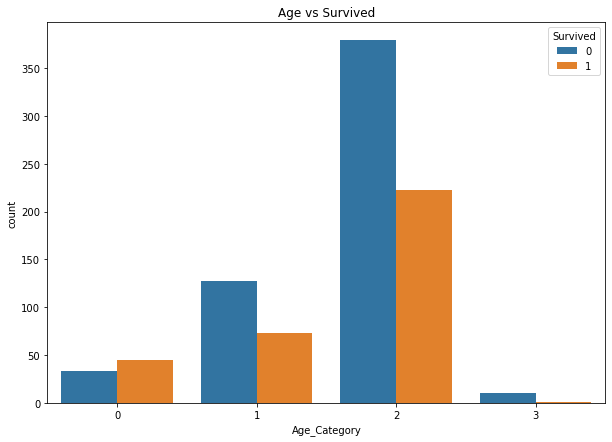

```python
fig, ax = plt.subplots(figsize=(10, 7))
sns.countplot('Age_Category', hue='Survived', data=num_vars)
ax.set_title('Age vs Survived')
plt.show()
```

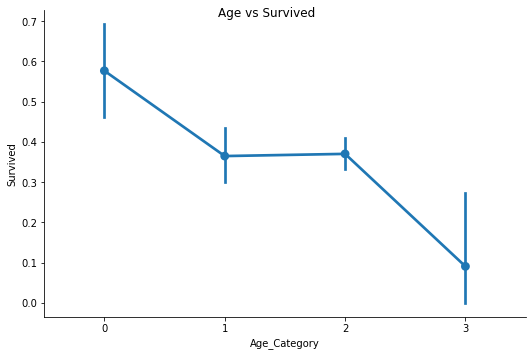

```python
fig = sns.factorplot('Age_Category', 'Survived', data=num_vars, size=5, aspect=1.5)
fig.fig.suptitle('Age vs Survived')
```

Highest survival rate for age category of 0 while least for 3.

#### 1.3 SibSp , Parch vs Survived

```python
num_vars['FamilyMembers'] = num_vars['SibSp'].astype('int64') + num_vars['Parch'].astype('int64')
test['FamilyMembers'] = test['SibSp'].astype('int64') + test['Parch'].astype('int64')
```

```python
num_vars['FamilyMembers'].dtype, test['FamilyMembers'].dtype
```

```
(dtype('int64'), dtype('int64'))
```

```python
num_vars.loc[:,['FamilyMembers', 'Survived']].groupby('FamilyMembers').mean()
```

| FamilyMembers | Survived |
| --- | --- |
| 0 | 0.303538 |
| 1 | 0.552795 |
| 2 | 0.578431 |
| 3 | 0.724138 |
| 4 | 0.200000 |
| 5 | 0.136364 |
| 6 | 0.333333 |
| 7 | 0.000000 |
| 10 | 0.000000 |

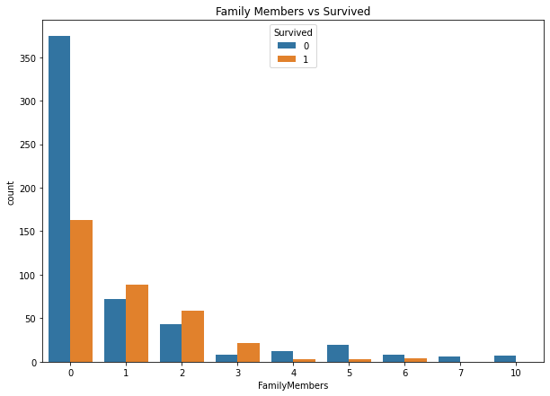

```python
fig, ax = plt.subplots(figsize=(10, 7))
sns.countplot('FamilyMembers', hue='Survived', data=num_vars)
ax.set_title('Family Members vs Survived')
plt.show()
```

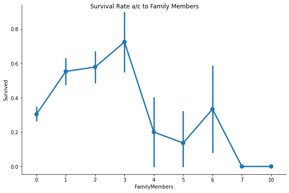

```python
fig = sns.factorplot('FamilyMembers', 'Survived', data=num_vars, size=5.5, aspect=1.5)
fig.fig.suptitle('Survival Rate a/c to Family Members')
```

Highest survival rate for passengers with 3 family members while least for 7 and 10.

#### 1.4 Fare vs Survived

```python
full_data['Fare'].isnull().sum()
```

```
1
```

```python
num_vars['Fare'].isnull().sum(), test['Fare'].isnull().sum()
```

```
(0, 1)
```

```python
mean_fare = full_data['Fare'].mean()
median_fare = full_data['Fare'].median()
```

```python
mean_fare, median_fare
```

```
(33.29547928134557, 14.4542)
```

```python
full_data.loc[full_data['Fare'].isnull(),'Fare'] = mean_fare
```

```python
full_data['Fare'].isnull().sum()
```

```
0
```

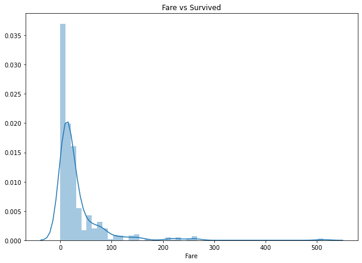

```python
fig, ax = plt.subplots(figsize=(10, 7))
sns.distplot(num_vars['Fare'])
ax.set_title('Fare vs Survived')
plt.show()
```

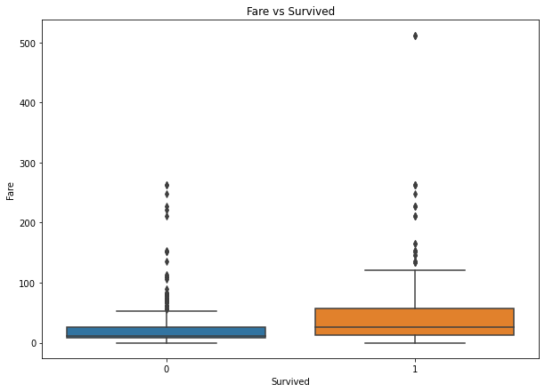

```python
fig, ax = plt.subplots(figsize=(10, 7))
sns.boxplot('Survived', 'Fare', data=num_vars)
ax.set_title('Fare vs Survived')
plt.show()
```

```python
# As boxplot shows above, there are some outliers exist in Fare. Firstly, remove them before further processing
fare_25 = np.percentile(num_vars['Fare'], 25)
fare_75 = np.percentile(num_vars['Fare'], 75)
fare_iqr = fare_75 - fare_25
```

```python
fare_25, fare_75, fare_iqr
```

```
(7.9104, 31.0, 23.0896)
```

```python
lower_bound = fare_25 - (1.5 * fare_iqr)
upper_bound = fare_75 + (1.5 * fare_iqr)
```

```python
lower_bound, upper_bound
```

```
(-26.724, 65.6344)
```

```python
new_train = train.copy()
new_train = new_train.loc[(new_train['Fare']>=lower_bound) & (new_train['Fare']<=upper_bound)].reset_index(drop=True)
num_vars = num_vars.loc[(num_vars['Fare']>=lower_bound) & (num_vars['Fare']<=upper_bound),:].reset_index(drop=True)
```

```python
num_vars['Fare'].min(), num_vars['Fare'].max()
```

```
(0.0, 65.0)
```

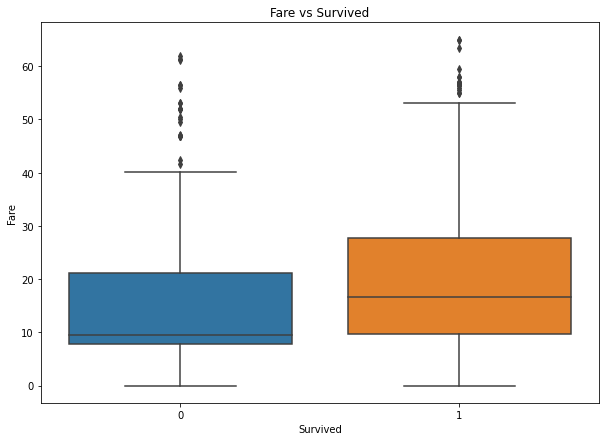

```python
fig, ax = plt.subplots(figsize=(10, 7))
sns.boxplot('Survived', 'Fare', data=num_vars)
ax.set_title('Fare vs Survived')
plt.show()
```

```python
pd.qcut(num_vars['Fare'], 5)
```

```
0      (-0.001, 7.775]
1       (7.775, 8.795]
2        (26.55, 65.0]
3       (7.775, 8.795]
4       (7.775, 8.795]
            ...
770    (8.795, 15.246]
771      (26.55, 65.0]
772    (15.246, 26.55]
773      (26.55, 65.0]
774    (-0.001, 7.775]
Name: Fare, Length: 775, dtype: category
Categories (5, interval[float64]): [(-0.001, 7.775] < (7.775, 8.795] < (8.795, 15.246] < (15.246, 26.55] < (26.55, 65.0]]
```

```python
num_vars['Fare_Category'] = 0
num_vars.loc[num_vars['Fare']<7.775, 'Fare_Category'] = 0
num_vars.loc[(num_vars['Fare']>=7.775) & (num_vars['Fare']<8.795), 'Fare_Category'] = 1
num_vars.loc[(num_vars['Fare']>=8.795) & (num_vars['Fare']<15.246), 'Fare_Category'] = 2
num_vars.loc[(num_vars['Fare']>=15.246) & (num_vars['Fare']<26.55), 'Fare_Category'] = 3
num_vars.loc[num_vars['Fare']>=26.55, 'Fare_Category'] = 4
```

```python
test['Fare_Category'] = 0
test.loc[test['Fare']<7.775, 'Fare_Category'] = 0
test.loc[(test['Fare']>=7.775) & (test['Fare']<8.795), 'Fare_Category'] = 1
test.loc[(test['Fare']>=8.795) & (test['Fare']<15.246), 'Fare_Category'] = 2
test.loc[(test['Fare']>=15.246) & (test['Fare']<26.55), 'Fare_Category'] = 3
test.loc[test['Fare']>=26.55, 'Fare_Category'] = 4
```

```python
num_vars.loc[:,['Fare_Category', 'Survived']].groupby('Fare_Category').mean()
```

| Fare_Category | Survived |
| --- | --- |
| 0 | 0.207143 |
| 1 | 0.194118 |
| 2 | 0.352564 |
| 3 | 0.489362 |
| 4 | 0.458333 |

```python
num_vars.head()
```

|  | Survived | Pclass | Age | SibSp | Parch | Fare | Age_Category | FamilyMembers | Fare_Category |
| --- | --- | --- | --- | --- | --- | --- | --- | --- | --- |
| 0 | 0 | 3 | 22.0 | 1 | 0 | 7.2500 | 1 | 1 | 0 |
| 1 | 1 | 3 | 26.0 | 0 | 0 | 7.9250 | 2 | 0 | 1 |
| 2 | 1 | 1 | 35.0 | 1 | 0 | 53.1000 | 2 | 1 | 4 |
| 3 | 0 | 3 | 35.0 | 0 | 0 | 8.0500 | 2 | 0 | 1 |
| 4 | 0 | 3 | 28.0 | 0 | 0 | 8.4583 | 2 | 0 | 1 |

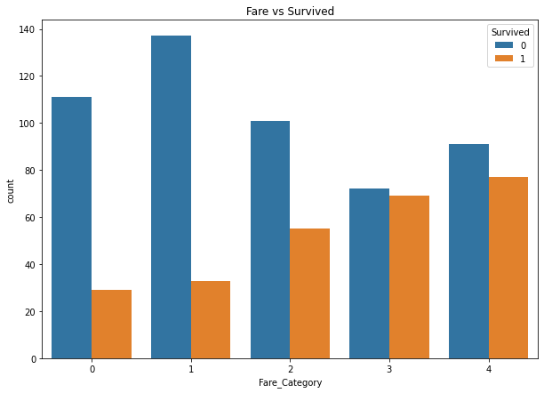

```python
fig, ax = plt.subplots(figsize=(10, 7))
sns.countplot('Fare_Category', hue='Survived', data=num_vars)
ax.set_title('Fare vs Survived')
plt.show()
```

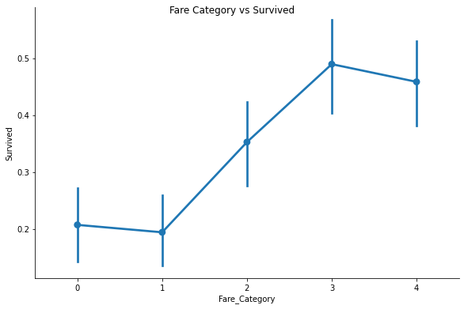

```python
fig = sns.factorplot('Fare_Category', 'Survived', data=num_vars, size=5.5, aspect=1.5)
fig.fig.suptitle('Fare Category vs Survived')
plt.show()
```

Increase in survival rate with the increase of Fare. There is slightly drop in survival rate for fare category 4 but overall there is increase.

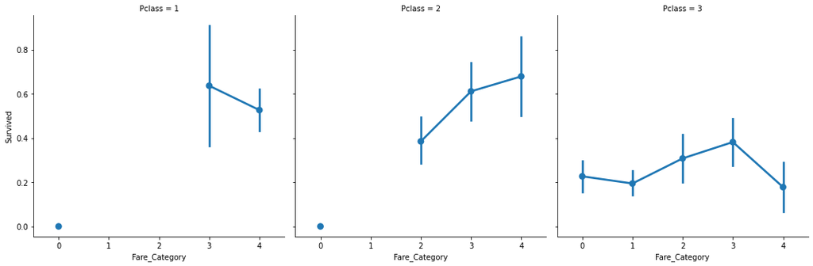

```python
# Since, there is an increase in survival rate with increase in fare as well as moving lower to standard in pclass.
# So, let's analyze of there is co-relation between Fare and Pclass
fig = sns.factorplot('Fare_Category', 'Survived', col='Pclass', data=num_vars)
```

It shows that high class people were given priority during rescue. High survival rate for high fare and pclass of 1 & 2.

```python
num_vars.columns
```

```
Index(['Survived', 'Pclass', 'Age', 'SibSp', 'Parch', 'Fare', 'Age_Category',
       'FamilyMembers', 'Fare_Category'],
      dtype='object')
```

```python
new_train.columns
```

```
Index(['PassengerId', 'Survived', 'Pclass', 'Name', 'Sex', 'Age', 'SibSp',
       'Parch', 'Ticket', 'Fare', 'Cabin', 'Embarked'],
      dtype='object')
```

```python
len(new_train), len(num_vars)
```

```
(775, 775)
```

### 2. Categorical Variables

```python
cat_vars = new_train.loc[:, new_train.dtypes == 'object']
cat_vars['Survived'] = new_train['Survived']
```

```python
cat_vars.head()
```

|  | Name | Sex | Ticket | Cabin | Embarked | Survived |
| --- | --- | --- | --- | --- | --- | --- |
| 0 | Braund, Mr. Owen Harris | male | A/5 21171 | NaN | S | 0 |
| 1 | Heikkinen, Miss. Laina | female | STON/O2. 3101282 | NaN | S | 1 |
| 2 | Futrelle, Mrs. Jacques Heath (Lily May Peel) | female | 113803 | C123 | S | 1 |
| 3 | Allen, Mr. William Henry | male | 373450 | NaN | S | 0 |
| 4 | Moran, Mr. James | male | 330877 | NaN | Q | 0 |

#### 2.1 Sex vs Survived

```python
cat_vars['Sex'].isnull().sum()
```

```
0
```

```python
cat_vars.loc[:,['Sex', 'Survived']].groupby('Sex').sum()
```

| Sex | Survived |
| --- | --- |
| female | 168 |
| male | 95 |

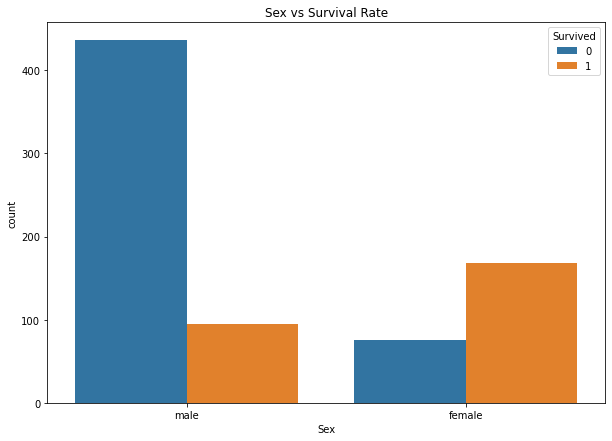

```python
fig, ax = plt.subplots(figsize=(10, 7))
sns.countplot('Sex', hue='Survived', data=cat_vars)
ax.set_title('Sex vs Survival Rate')
plt.show()
```

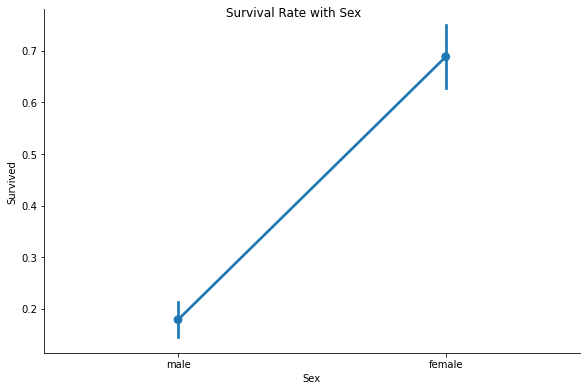

```python
# It's clearly seen that females were given priority during rescue. Let's plot factorplot
fig = sns.factorplot('Sex', 'Survived', data=cat_vars, size=5.5, aspect=1.5)
fig.fig.suptitle('Survival Rate with Sex')
plt.show()
```

#### 2.2 Embarked vs Survived

```python
cat_vars['Embarked'].isnull().sum()
```

```
0
```

```python
cat_vars.loc[:,['Embarked', 'Survived']].groupby('Embarked').mean()
```

| Embarked | Survived |
| --- | --- |
| C | 0.448276 |
| Q | 0.386667 |
| S | 0.311644 |

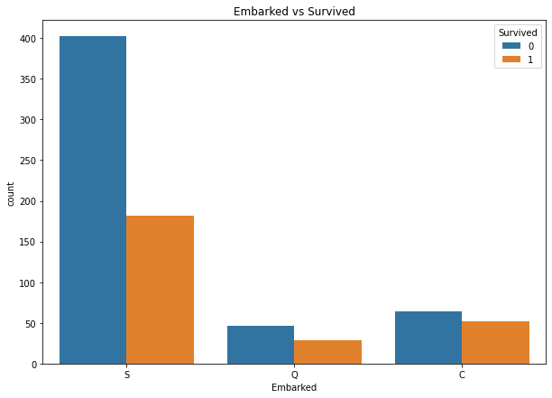

```python
fig, ax = plt.subplots(figsize=(10, 7))
sns.countplot('Embarked', hue='Survived', data=cat_vars)
ax.set_title('Embarked vs Survived')
plt.show()
```

Highest survival rate for those with Embarked=C while least for Embarked=S

#### 2.3 Cabin vs Survived

```python
cat_vars['Cabin'].isnull().sum()
```

```
661
```

```python
print('Percentage of Null values in Cabin: {}. That;s why Cabin will not be considered for further analysis and modeling.'.format(round(cat_vars['Cabin'].isnull().sum()/len(cat_vars), 3)*100))
```

```
Percentage of Null values in Cabin: 85.3. That;s why Cabin will not be considered for further analysis and modeling.
```

```python
cat_vars.drop('Cabin', axis=1, inplace=True)
test.drop('Cabin', axis=1, inplace=True)
```

#### 2.4 Ticket vs Survived

```python
cat_vars['Ticket'].isnull().sum()
```

```
0
```

```python
cat_vars['Ticket'].value_counts()
```

```
1601       7
347082     7
347088     6
CA 2144    6
3101295    6
          ..
2687       1
3101264    1
349221     1
248731     1
2620       1
Name: Ticket, Length: 632, dtype: int64
```

No null values in Ticket but ambigious values. That's why it will not be part of further analysis.

```python
cat_vars.drop('Ticket', axis=1, inplace=True)
test.drop('Ticket', axis=1, inplace=True)
```